# Занятие 1: Знакомство с программой PyMol

### Лев Мазаев, мАДБМ18

```python
import xmlrpc.client as xmlrpclib
import time
cmd = xmlrpclib.ServerProxy('http://localhost:9123')
from IPython.display import Image
```

```python
cmd.fetch('1MBN')
```

```
'1MBN'
```

```python
cmd.do('as lines')
```

```python
cmd.do('as sticks')
```

```python
cmd.do('as cartoon')
```

```python
cmd.do('as ribbon')
```

```python
cmd.do('as spheres')
```

```python
# Экспорт изображения шариковой модели структуры
cmd.do('''
orient
ray 800, 600
png all.png
''')
```

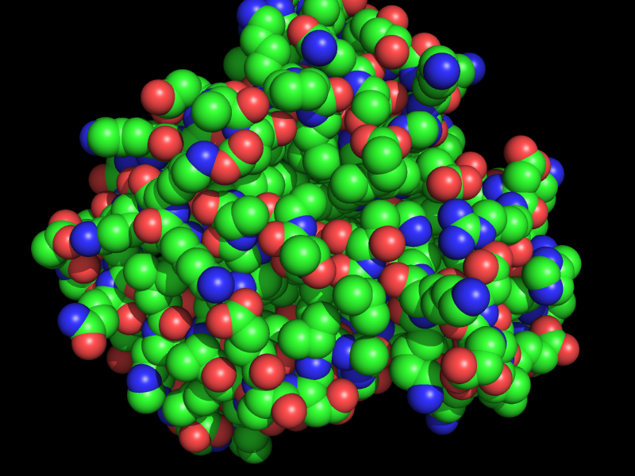

```python
Image('all.png')
```

Далее команды, которые порождают необходимые картинки.

1. Вся структура в шариковой модели - была выше.
2. Структура только белка в остовной модели (остовная модель - атомы ca):

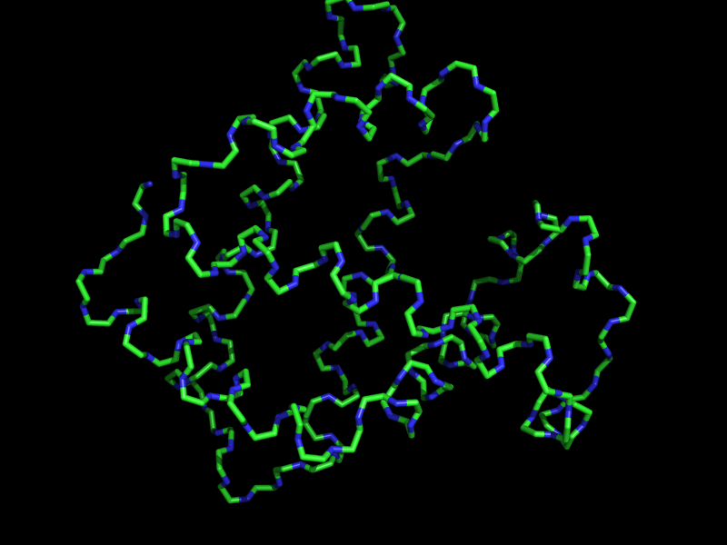

```python
cmd.do('''
hide everything
show sticks, name ca+c+n
orient
ray 800, 600
png img.png
''')
time.sleep(.1)
Image('img.png')
```

1. Структура только белка в ленточной модели:

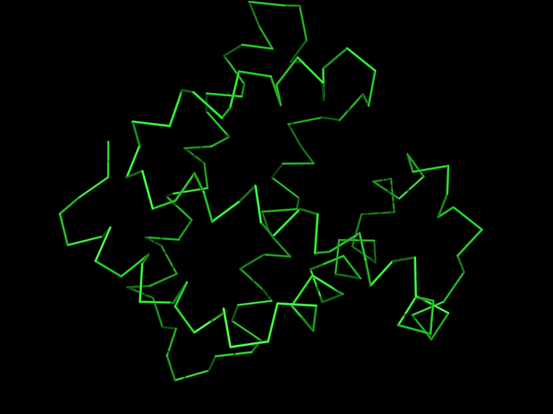

```python
cmd.do('''
hide everything
show ribbon, polymer
orient
ray 800, 600
png img.png
''')
time.sleep(.1)
Image('img.png')
```

1. Изображение всех компонентов структуры:

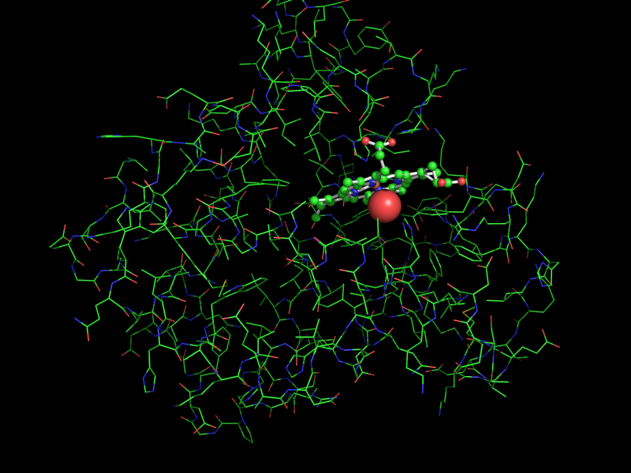

```python
cmd.do('''
hide everything
show lines, polymer
show spheres, solvent
set_bond stick_color, white, organic
set_bond stick_radius, 0.14, organic
set sphere_scale, 0.25, organic
show sticks, organic
show spheres, organic
orient
ray 800, 600
png all_components.png
''')
time.sleep(.1)
Image('all_components.png')
```

1. Изображение концевых остатков у одной полипептидной цепи (у модели есть только одна цепь - chain A):

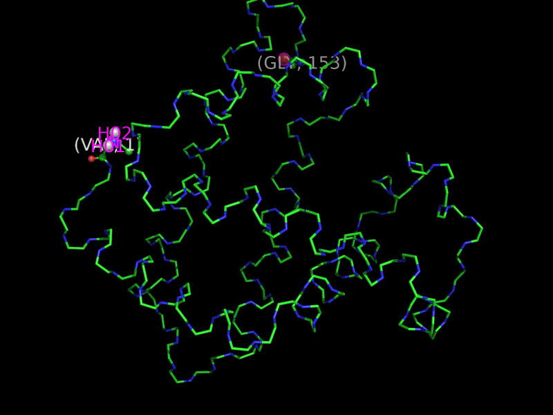

```python
cmd.do('''
hide everything
set_bond stick_radius, 0.14, polymer
set sphere_scale, 0.25, polymer
set sphere_scale, 0.25, hydrogens
set label_size, 20
show sticks, name ca+c+n
sel nterm, resi 1
sel cterm, resi 153
label n. CA and i. 1, "(%s, %s)" % (resn, resi)
label n. CA and i. 153, "(%s, %s)" % (resn, resi)
show spheres, nterm
show sticks, nterm
show spheres, cterm
show sticks, cterm
sel aminogroup, name N and resi 1
h_add aminogroup
sel aminogroup, (name N or name H01 or name H02) and resi 1
label aminogroup, name
sel oxygen, name O and resi 153
label oxygen, name
set sphere_scale, 0.5, aminogroup
set sphere_scale, 0.5, oxygen
set label_color, magenta, aminogroup
set label_color, magenta, oxygen
orient
ray 800, 600
png img.png
''')
time.sleep(.1)
Image('img.png')
```

### Дополнительные упражения

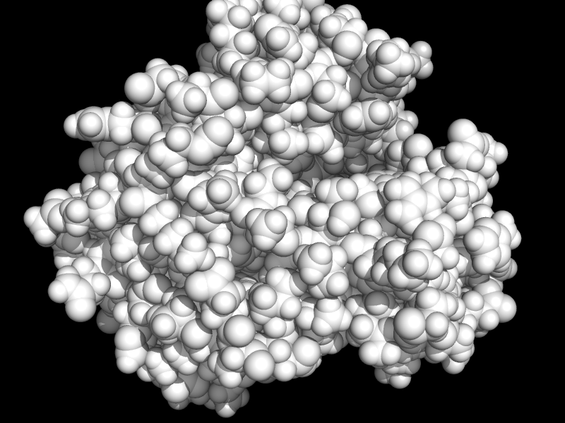

```python
cmd.do('''
hide everything
h_add
set sphere_scale, 1, (all)
set sphere_color, white, (all)
show spheres, polymer
ray 800, 600
png img.png
''')
time.sleep(.1)
Image('img.png')
```

По форме этот белок похож на сдавленный мяч, правда с некоторыми выпуклыми элементами. Расстояние между самыми дальними атомами (атомы выбирались примерно) - 49 ангстрем, то есть 4.9 нм или 0.0049 мкм. Посчитаем сколько таких белков поместится в одной клетке *Escherichia coli*, если аппроксимировать клетку цилиндром r=0.5µm и h=2µm.

```python
from math import pi
r_prot = 0.0049 / 2
v_prot = 4 * pi * r_prot**3 / 3
v_cell = 2 * pi * 0.5**2
print(f'Объем одного белка - {v_prot} куб. мкм')
print(f'Объем клетки - {v_cell} куб. мкм')
print(f'Примерно {round(v_cell/v_prot)} молекул белка поместится в одной клетке Escherichia coli')
```

```
Объем одного белка - 6.160087235036426e-08 куб. мкм
Объем клетки - 1.5707963267948966 куб. мкм
Примерно 25499579 молекул белка поместится в одной клетке Escherichia coli
```

Сколькими молекулами будет представлен каждый белок, если все 4400 белков кишечной палочки были синтезированы одновременно и в равных количествах?

```python
print(f'Примерно {round(v_cell / v_prot / 4400)} молекулами будет представлен каждый белок')
```

```
Примерно 5795 молекулами будет представлен каждый белок
```

Пусть длина волны видимого (в данном случае) света - 400 нм, тогда предел разрешения светового микроскопа - 200 нм. Получается, нужно посчитать сколько молекул белка нужно, чтобы создать квадрат со сторонами примерно 200 нм (скорее круг, но порядок величины будет примерно одинаковый).

Так как длина одной молекулы белка ~5 нм, то цепочка молекул белка длиной 200 нм составляется из 40 белков. Чтобы сделать квадрат с соответствующей стороной, потребуется 1600 молекул белка. Примерно столько нужно молекул, чтобы создать объект, видимый под световым микроскопом.